# Practical Machine Learning Assignment

Ravishankar Doejode - January 31st, 2016.

## Synopsis

The goal of the analysis described in the document is to predict the way people performed barbell lifts by training/testing different prediction models on data from accelerometers of the wearable fitness monitoring devices. The prediction is done using models from different Machine Learning techniques. Per the details on the data, the data is from the wearable devices on the belt, forearm, arm, and dumbell of 6 participants. The list below shows 5 different ways,correctly and incorrectly, the barbell lifts were done.

- Class A:Exactly according to the specification
- Class B:Throwing the elbows to the front
- Class C:Lifting the dumbbell only halfway
- Class D:Lowering the dumbbell only halfway
- Class E:Throwing the hips to the front

## Data Processing

All the required libaries are loaded using the R code below. The training (pml-training.csv) and testing data (pml-testing.csv) is also loaded with the code below. The testing data (dataframe is “testing_Quiz”) will be used to answer the quiz questions.

```r
library(ggplot2)
library(randomForest)
library(rpart)
library(rpart.plot)
library(MASS)
library(party)
library(caret)


setwd("/Users/bdcoe/Documents/r/coursera/MachineLearning/Project")
training <-read.csv("pml-training.csv",header=TRUE,na.strings=c("NA","#DIV/0!", ""))
testing_Quiz <- read.csv("pml-testing.csv",header=TRUE,na.strings=c("NA","#DIV/0!", ""))
dim(training)
```

```
## [1] 19622   160
```

The training data has 19,622 observations with 160 different variables. The variable **“classe”** has the way (A-E) the lifting was performed. A whole bunch of variables have only NAs for value. It would make sense to just drop all the columns that have just the NA values. Columns 1 through 7 have data that is not needed with the analysis. The code below gets rid of NAs filled columns and columns 1 through 7.

```r
training<-training[,colSums(is.na(training)) == 0]
training<-training[,-c(1:7)]

testing_Quiz<-testing_Quiz[,colSums(is.na(testing_Quiz)) == 0]
testing_Quiz<-testing_Quiz[,-c(1:7)]
dim(training)
```

```
## [1] 19622    53
```

```r
dim(testing_Quiz)
```

```
## [1] 20 53
```

The seed is set to 1214. Setting the seed will allow for reproducibility of the results. We will make a train and test dataset with a 70 and 30 split. The train dataset will be used to train the model and test dataset will be used to do the cross validation.

```r
set.seed(1214)
Intrain<-createDataPartition(training$classe,p=0.7,list=FALSE)

train<-training[Intrain,]
test<-training[-Intrain,]
```

## Machine Learning Modeling

With this PML dataset, we are required to predict the **“classe”** of the barbell lift. We need a classification model and not any of the other models (Scoring, ranking, clustering). Recursive partitioning, conditional inference trees and random forest are some of the models we could look at using. With the classification model, the most important measure of classifier quality is accuracy. Accuracy could be measured by using confusion matrix tool. We will be using confusion matrix to assess the quality of each of the models

We will finally use the best model to answer the submission quiz questions.

## Recursive Partitioning and Regression Trees

We will start with recursive partitioning

```r
modelrpart <- rpart(classe ~ ., data=train, method="class")
predictionrpart <- predict(modelrpart, test, type = "class")
confusionMatrix(predictionrpart, test$classe)
```

```
## Confusion Matrix and Statistics
##
##           Reference
## Prediction    A    B    C    D    E
##          A 1493  242   20  107   36
##          B   46  588   52   20   78
##          C   44  155  828  149  117
##          D   56   79   55  602   54
##          E   35   75   71   86  797
##
## Overall Statistics
##
##                Accuracy : 0.732
##                  95% CI : (0.7205, 0.7433)
##     No Information Rate : 0.2845
##     P-Value [Acc > NIR] : < 2.2e-16
##
##                   Kappa : 0.6597
##  Mcnemar's Test P-Value : < 2.2e-16
##
## Statistics by Class:
##
##                      Class: A Class: B Class: C Class: D Class: E
## Sensitivity            0.8919  0.51624   0.8070   0.6245   0.7366
## Specificity            0.9038  0.95870   0.9043   0.9504   0.9444
## Pos Pred Value         0.7866  0.75000   0.6404   0.7116   0.7491
## Neg Pred Value         0.9546  0.89198   0.9569   0.9282   0.9409
## Prevalence             0.2845  0.19354   0.1743   0.1638   0.1839
## Detection Rate         0.2537  0.09992   0.1407   0.1023   0.1354
## Detection Prevalence   0.3225  0.13322   0.2197   0.1438   0.1808
## Balanced Accuracy      0.8978  0.73747   0.8557   0.7874   0.8405
```

```r
table(predictionrpart, test$classe)
```

```
##
## predictionrpart    A    B    C    D    E
##               A 1493  242   20  107   36
##               B   46  588   52   20   78
##               C   44  155  828  149  117
##               D   56   79   55  602   54
##               E   35   75   71   86  797
```

Recursive partiioning yielded an accuracey of 0.732. Below is the tree plot.

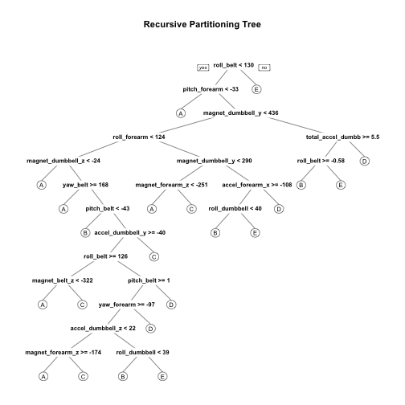

```r
rpart.plot(modelrpart, main="Recursive Partitioning Tree")
```

We will press on with the other models.

## Conditional Inference Trees

We will next use conditional inference tree

```r
modelctree <- ctree(classe ~ ., data=train)
predictionctree <- predict(modelctree, test)
confusionMatrix(predictionctree, test$classe)
```

```
## Confusion Matrix and Statistics
##
##           Reference
## Prediction    A    B    C    D    E
##          A 1549   59   16   31   21
##          B   68  952   48   34   36
##          C   15   52  901   63   32
##          D   26   41   31  825   31
##          E   16   35   30   11  962
##
## Overall Statistics
##
##                Accuracy : 0.8817
##                  95% CI : (0.8732, 0.8899)
##     No Information Rate : 0.2845
##     P-Value [Acc > NIR] : < 2e-16
##
##                   Kappa : 0.8504
##  Mcnemar's Test P-Value : 0.01041
##
## Statistics by Class:
##
##                      Class: A Class: B Class: C Class: D Class: E
## Sensitivity            0.9253   0.8358   0.8782   0.8558   0.8891
## Specificity            0.9698   0.9608   0.9667   0.9738   0.9808
## Pos Pred Value         0.9242   0.8366   0.8476   0.8648   0.9127
## Neg Pred Value         0.9703   0.9606   0.9741   0.9718   0.9752
## Prevalence             0.2845   0.1935   0.1743   0.1638   0.1839
## Detection Rate         0.2632   0.1618   0.1531   0.1402   0.1635
## Detection Prevalence   0.2848   0.1934   0.1806   0.1621   0.1791
## Balanced Accuracy      0.9476   0.8983   0.9224   0.9148   0.9350
```

```r
table(predictionctree, test$classe)
```

```
##
## predictionctree    A    B    C    D    E
##               A 1549   59   16   31   21
##               B   68  952   48   34   36
##               C   15   52  901   63   32
##               D   26   41   31  825   31
##               E   16   35   30   11  962
```

Conditional Inference tree yielded an accuracy of 0.8817.

## Random Forest

We will now use random forest to see if accuracy of prediction could be improved upon.

```r
modelrf <- randomForest(classe ~ ., data=train, method="class")
predictionrf <- predict(modelrf, test, type = "class")
confusionMatrix(predictionrf, test$classe)
```

```
## Confusion Matrix and Statistics
##
##           Reference
## Prediction    A    B    C    D    E
##          A 1674    2    0    0    0
##          B    0 1137    2    0    0
##          C    0    0 1019    3    0
##          D    0    0    5  961    2
##          E    0    0    0    0 1080
##
## Overall Statistics
##
##                Accuracy : 0.9976
##                  95% CI : (0.996, 0.9987)
##     No Information Rate : 0.2845
##     P-Value [Acc > NIR] : < 2.2e-16
##
##                   Kappa : 0.997
##  Mcnemar's Test P-Value : NA
##
## Statistics by Class:
##
##                      Class: A Class: B Class: C Class: D Class: E
## Sensitivity            1.0000   0.9982   0.9932   0.9969   0.9982
## Specificity            0.9995   0.9996   0.9994   0.9986   1.0000
## Pos Pred Value         0.9988   0.9982   0.9971   0.9928   1.0000
## Neg Pred Value         1.0000   0.9996   0.9986   0.9994   0.9996
## Prevalence             0.2845   0.1935   0.1743   0.1638   0.1839
## Detection Rate         0.2845   0.1932   0.1732   0.1633   0.1835
## Detection Prevalence   0.2848   0.1935   0.1737   0.1645   0.1835
## Balanced Accuracy      0.9998   0.9989   0.9963   0.9977   0.9991
```

```r
table(predictionrf, test$classe)
```

```
##
## predictionrf    A    B    C    D    E
##            A 1674    2    0    0    0
##            B    0 1137    2    0    0
##            C    0    0 1019    3    0
##            D    0    0    5  961    2
##            E    0    0    0    0 1080
```

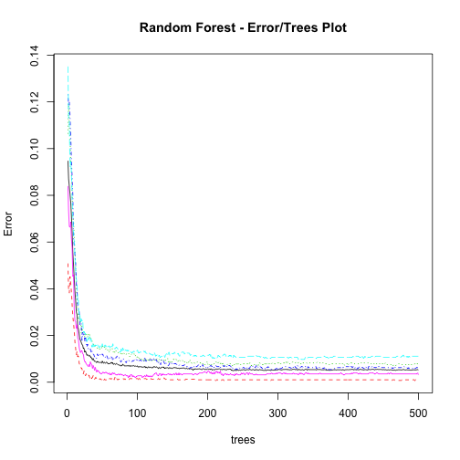

```r
plot(modelrf, main="Random Forest - Error/Trees Plot")
```

Random forest yielded an accuracy of 0.9976. This is the best accuracy of all the three models we have tried so far. Recursive partitioning and conditional inference tree yielded an accuracy of 0.732 and 0.8817 respectively.

### Out of sample error

Out of sample error is 1 - accuracy, which is 0.0024 if we go with random forest model.

### Submission - Applying the model on the final quiz data

Things cannot get any better than an accuracy of 0.9976 and we will stop here and use the model on the testing_Quiz data to find the **“classe”** for this test dataset.

```r
dim(testing_Quiz)
```

```
## [1] 20 53
```

We have about 20 observations with the testing data that will be used to answer the quiz questions.

```r
predictTest<-predict(modelrf,testing_Quiz,type="class")
predictTest
```

```
##  1  2  3  4  5  6  7  8  9 10 11 12 13 14 15 16 17 18 19 20
##  B  A  B  A  A  E  D  B  A  A  B  C  B  A  E  E  A  B  B  B
## Levels: A B C D E
```

### Reference

Ugulino, W.; Cardador, D.; Vega, K.; Velloso, E.; Milidiu, R.; Fuks, H. Wearable Computing: Accelerometers' Data Classification of Body Postures and Movements. Proceedings of 21st Brazilian Symposium on Artificial Intelligence. Advances in Artificial Intelligence - SBIA 2012. In: Lecture Notes in Computer Science. , pp. 52-61. Curitiba, PR: Springer Berlin / Heidelberg, 2012. ISBN 978-3-642-34458-9. DOI: 10.1007/978-3-642-34459-6_6.

Read more: http://groupware.les.inf.puc-rio.br/har#sbia_paper_section#ixzz3yhDQ8tUe